# Kelp Wrack Data Summary

Data collected at Bandon Beach from 2018-2021

David Bilderback, Oregon Institute of Marine Biology

Ross Whippo, NOAA - NCCOS

Created: 2022-04-01 ; (Updated: 2023-11-07)

# 1 Abstract

Hi Dave, here’s an updated version of some of the visualizations. I have put the newer figures that you requested toward the top.

## 1.1 Keywords

# 2 Introduction

Kelp gametophytes can persist for up to 18 months, and may not produce gametes immediately (Dobkowski, Flanagan, and Nordstrom (2019), Dieck (1993)).

# 3 Methods

## 3.1 Study site

Location - A large and a smaller ancillary kelp bed of *Nereocystis luetkeana* (K. Martens) Postels & Ruprecht lie about 741 and 528 m, respectfully, off the coast at Bandon, Oregon. The large kelp bed with a surface area of about 355 m² is leeward of a rocky complex about 300 m long with a heading of 43.2°. The smaller kelp bed with a surface area of about 30 m² is leeward of a large rock. The nearest kelp beds to the north and south of these beds are about 13 and 28 km, respectively.

[interactive chart not shown]

## 3.2 Field surveys

### 3.2.1 Sampling Transect

Preliminary observations indicated that Nereocystis sporophytes of all ages wash up on the beach at Bandon. The beach is a high energy one with a wide surf zone consisting of three or more sand bars and troughs and a low sloping, wide beach of fine, mature sand. Waves break on the sand bars, thereby dissipating their energy as they move more gently over the low gradient beach. The beach experiences a semidiurnal tide with two high tides of unequal sizes each day.

### 3.2.2 Data collection

Sporophytes with stipes ranging from 0.5 to 180 cm. To investigate the recruitment of young sporophytes of Nereocystis, all small sporophytes with at least a holdfast, stipe and bulb (pneumatocyst) were collected from the beach each survey day and brought to the laboratory to be measured. From 4/8/2018 to 12/31/2021, the length of the stipe was measured to the nearest mm from the attachment with the holdfast to the base of the bulb, the type of substrate was determined and the associated cospecies of algae were identified. Whether a young sporophyte was a single individual or a member of an association of Nereocystis sporophytes was noted. From 7/12/2018 to 12/31/2021, the bulb diameter was determined to the nearest mm with a caliper. From 6/30/2019 to 12/31/2021, the diameter of the holdfast was measured to the nearest mm. From 7/11/2019 to 12/31/2021, the widest blade on the young sporophyte was measured to the nearest mm.

On October 20, 21, 24 and 26, 2018; November 3 and 4, 2018 and May 10, 15, 17, 18 and 21, 2019, all young intact and partial sporophytes were counted on the beach. Partial sporophytes could lack a holdfast or a holdfast and a portion of the stipe. Stipes that were either physically snapped or subjected to herbivory were noted.

Immature and reproductively mature sporophytes with stipes longer than 180 cm. Only intact, untangled Nereocystis sporophytes were measured. Only a few reproductively mature sporophytes had stipes less than 180 cm in length. Initially, the study focused on the production of reproductive sori by Nereocystis but was expanded to include Nereocystis sporophyte stipe lengths, widest blade widths and bulb (pneumatocyst) diameters. From 4/18/2018 to 7/10/2021, the number of maturing sori, the number of sori releasing propagules and the number of abscised sori on the widest blade on each Nereocystis sporophyte was recorded. The presence and type of epiphytes and/or epizootics on the Nereocystis stipes also was noted. After 6/14/2018 the length of the stipe of the intact Nereocystis sporophyte was recorded to the nearest cm. Because the boundaries between the stipe and bulb were ill-defined, the stipe was measured from the holdfast to 15 cm below blade attachment to the bulb. By 7/4/2018 the width of the widest blade of the sporophyte to a tenth of a cm was consistently recorded. On 7/13/2018 the circumference of the bulb to a tenth of a cm was noted in the field and transformed to a bulb diameter using a Circumference Calculator created by Bonga Szyk and Mateusz Muncha at omnicalculator.com. This full array of data was recorded in an Excel file until the conclusion of this portion of the study on 7/10/2021.

To investigate the complexity of Nereocystis canopy, sporophytes were randomly selected on February 25, March 4, 5 and 13, 2020, and the number of blades of each sporophyte were counted, and the longest and widest blade of each sporophyte were measured. From March 22 to March 31, 2021, 10 sporophytes were randomly selected, and the length of each stipe was recorded. For each of these sporophytes, the number of fertile blades with sori and sterile blades without sori were counted and the width of every fertile blade was noted. For each blade, the number of sori, the number of sori releasing or having released propagules and the number of abscised sori were noted. Also, for each fertile blade, the length and width of the fertile zone of sori, the length and width of zone with a sorus releasing or having released propagules, and the distance from proximal end of the fertile zone to the petiole attachment were recorded.

The canopy wet weight of the blades and bulb of randomly selected sporophytes was determined by excising the blades and bulb from the stipe 15 cm below the attachment of the blades to the bulb on May 5, 6, 7 and 9, 2019, washing them in sea water to remove sand, draining off the excess sea water and weighing them with a Modern Step hanging scale.  
To determine the nature of the propagules produced by Nereocystis sori, portions of ripe sori from freshly stranded Nereocystis were collected in plastic bags with cold sea water on 12/28-29/2019 and 1/11/2020. A sorus and sea water were transferred to a finger bowl. More cold sea water was added to the finger bowl and set aside at room temperature. Occasionally, the sorus was washed with sea water from a pipette. After a green film formed on the bottom of the finger bowl, a sample was pipetted onto a slide and a cover slip applied. The sample was examined with a compound scope and photographed.

Preliminary observations indicated that reproductive sori are initiated at the tip of the blade. These sori are long, narrow and tapered at their tips (Type 1). Subsequent sori are initiated proximally, and those formed midblade are wide and rectangular (Type 2). As soral initiation approaches 20 cm of the base of the blade, the sori become smaller and square in shape (Type 3). To investigate sorus sequencing and development, data was gathered on all individual, maturing or mature Nereocystis from 4/11/2021 to 5/28/2022. Each sporophyte was assessed whether it had overwintered or began development in the current year. Overwintering sporophytes have epiphytes and epizootics on the holdfast, a dull, dark brown stipe and usually, a heavy load of epiphytes on the stipe. The blades of overwintering sporophytes also may be large and wide. Sporophytes that began development during the current year have little or no epiphytes and epizootics on the holdfast, a glossy, olive-green stipe with little or no epiphytes on the stipe. The presence and the type of epiphytes on the stipe were noted. The presence of blades with Type 1, 2 or 3 sori on the sporophyte was noted, and the width of the widest blade with each type of sorus was recorded. For the widest blade with each type of sorus, the number of sori, the number of sori releasing propagules and the number of abscised sori was recorded. For blades with Type 3 sori, the distance from the proximal end of the fertile zone to the base of the petiole was measured as well as the length and width of the fertile zone. For immature sporophytes the width of the widest blade was noted .

To determine why sporophytes wash up on the beach, the basal portion of every untangled sporophyte was examined from 4/7/2021 to 4/19/2022. The number of stipes with an intact holdfast, the number of stipes with an intact holdfast with haptera subjected to herbivory and/or burrowing, the number of stipes with only a portion of the holdfast and the number of stipes without a holdfast were recorded. Evidence of urchin (Strongylocentrotus purpuratus) herbivory also was noted.

## 3.3 Data Analysis

# 4 Results

## 4.1 When are the recruitment pulses for the different cohorts of sporophytes across the year?

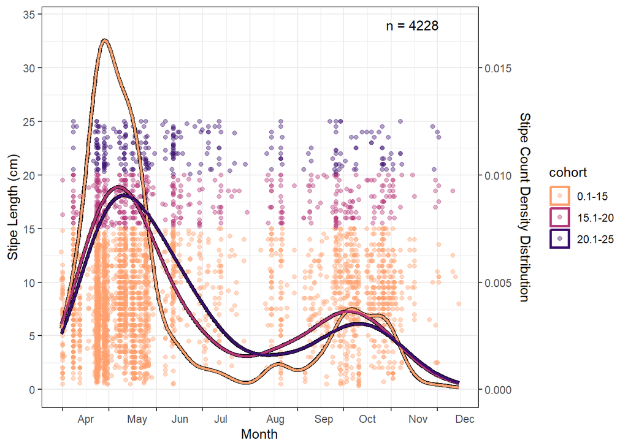

## 4.2 How does this compare to mature wrack?

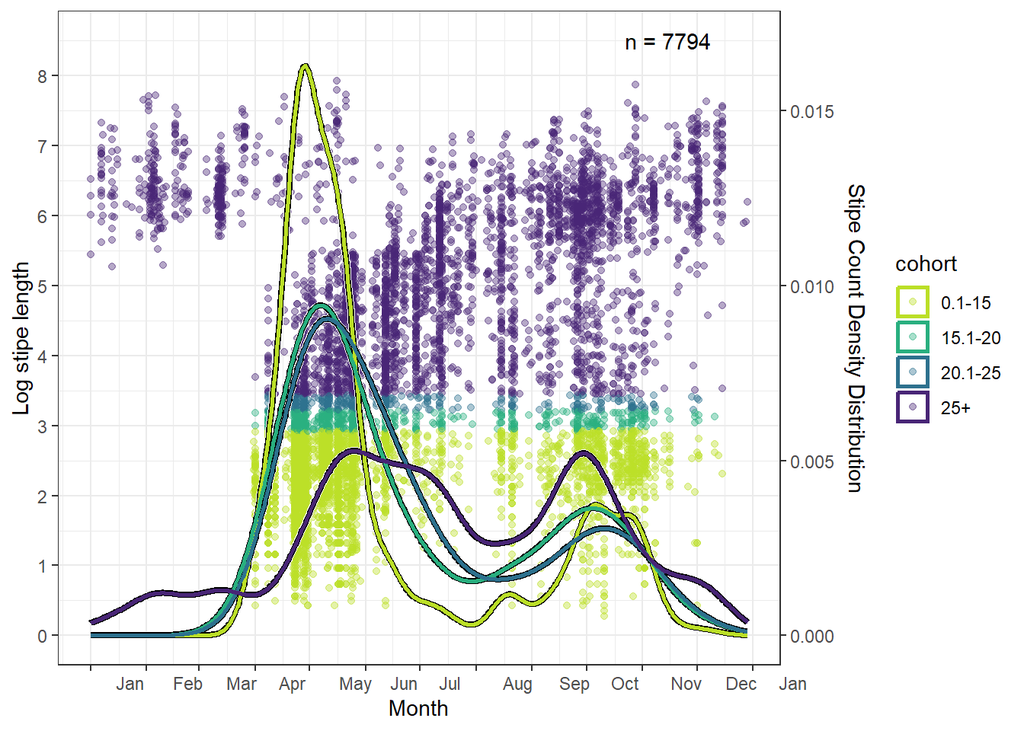

## 4.3 What does this look like in different years?

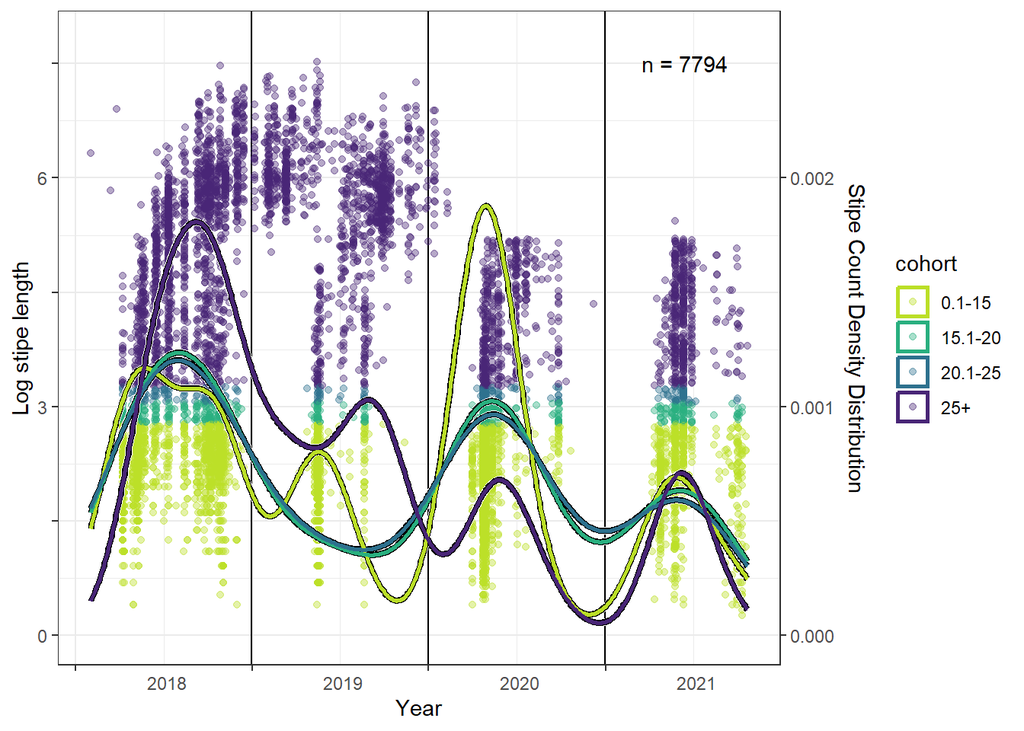

## 4.4 What is the total flux on intact kelp sporophyte wrack?

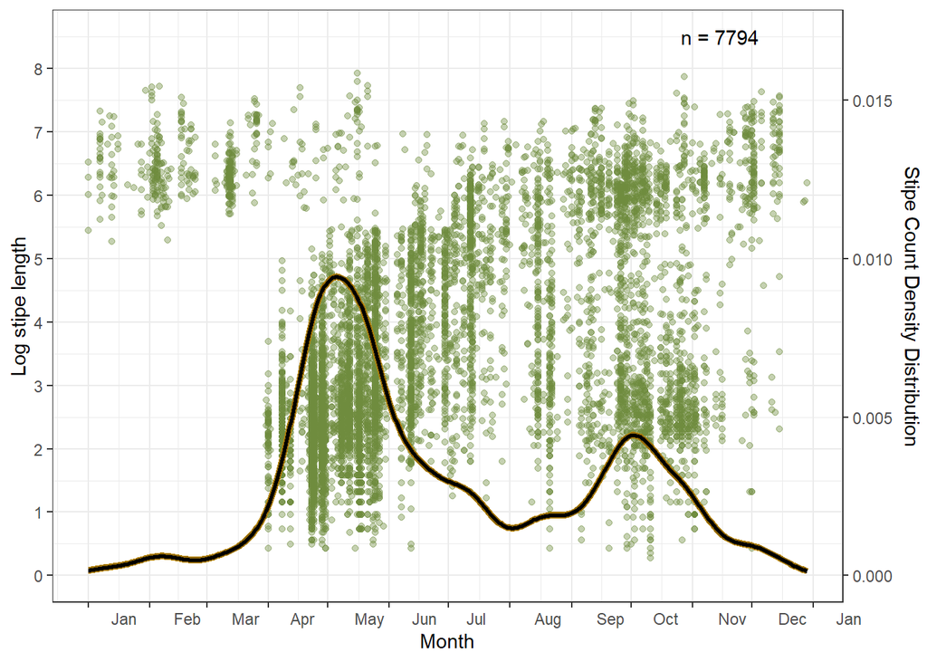

## 4.5 When do we see ‘secondary recruits’?

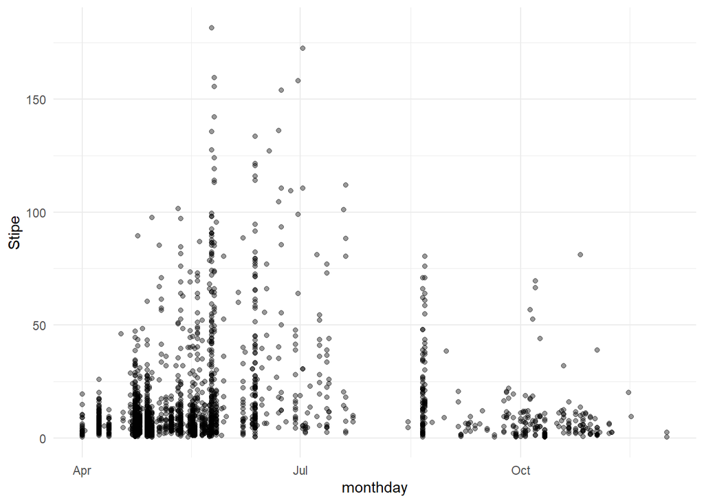

## 4.6 Is there a relationship between stipe length and bulb diameter?

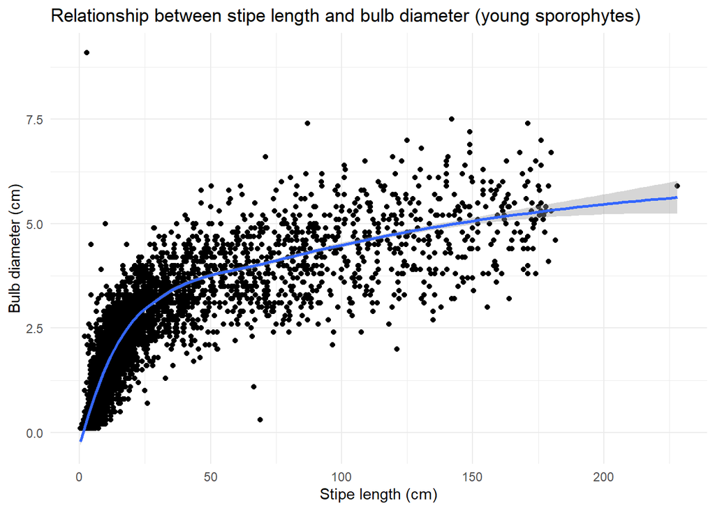

## 4.7 What is the mean diameter of holdfasts?

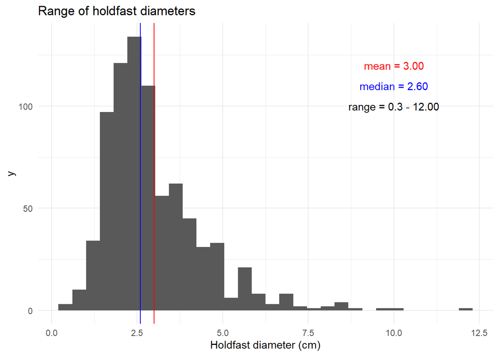

## 4.8 Is there a relationship between stipe length and blade width?

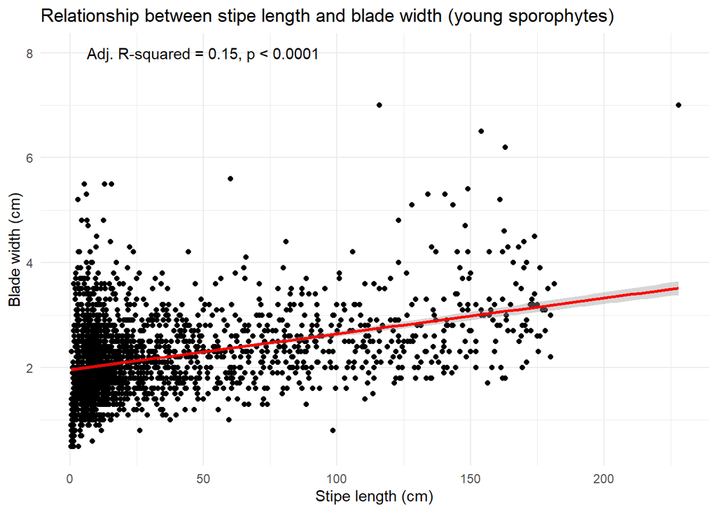

## 4.9 For each of the four years, how many days was the beach transect surveyed for young sporophytes?

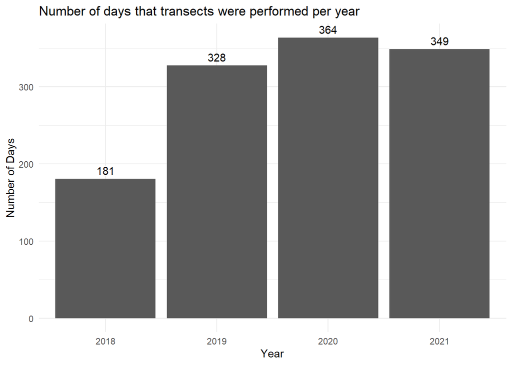

## 4.10 For each of the four years how many days were young sporophytes found on the transect?

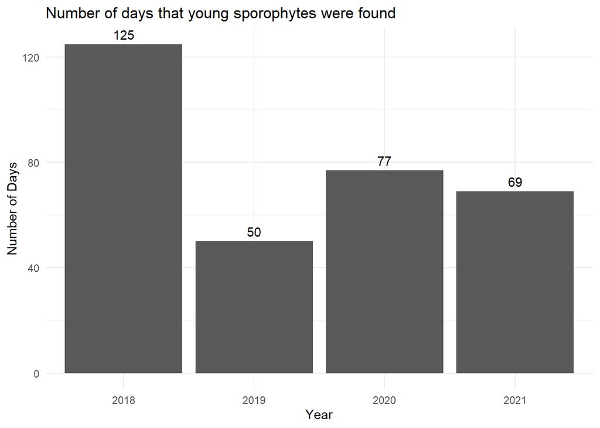

## 4.11 For each year, how many sporophytes were singular, and how many were clusters?

| year | Single | length(year) |
| --- | --- | --- |
| 2018 | multiple | 774 |
| 2018 | single | 1571 |
| 2019 | multiple | 464 |
| 2019 | single | 290 |
| 2020 | multiple | 1234 |
| 2020 | single | 618 |
| 2021 | multiple | 699 |
| 2021 | single | 401 |

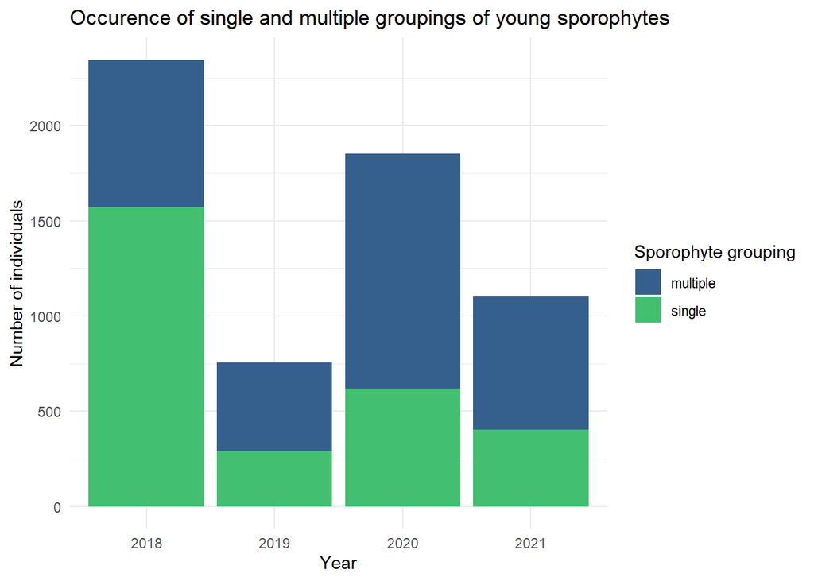

## 4.12 What is the count and percentage of each substrate type?

| Substrate | total | percent |
| --- | --- | --- |
| Nereocystis luetkeana | 2380 | 39.7660819 |
| unknown | 1736 | 29.0058480 |
| Barnacles-Balanus crenatus | 605 | 10.1086048 |
| Laminaria setchellii | 587 | 9.8078530 |
| Myriogramme variegata | 502 | 8.3876358 |
| Pterygophora californica | 38 | 0.6349206 |
| rock | 35 | 0.5847953 |
| shell | 20 | 0.3341688 |
| mussel-Mytilus califorianus | 14 | 0.2339181 |
| Cystoseira osmundacea | 9 | 0.1503759 |
| Chiton-Mopalia hindsii | 7 | 0.1169591 |
| Sponge-Halichondria panicea | 7 | 0.1169591 |
| Callophyllis crenulata | 6 | 0.1002506 |
| Gooseneck barnacle-Pollicipes polymerus | 5 | 0.0835422 |
| Hymenia flabelligera | 5 | 0.0835422 |
| Egregia menziesii | 4 | 0.0668338 |
| Pleurophycus gardneri | 4 | 0.0668338 |
| Bryozoa-Celleporella | 3 | 0.0501253 |
| Cryptopleura ruprechtiana | 3 | 0.0501253 |
| Callophyllis fabellulata | 2 | 0.0334169 |
| Dodecaceria fewkesi | 2 | 0.0334169 |
| Polyneura latissima | 2 | 0.0334169 |
| Unknown Blade | 2 | 0.0334169 |
| Alaria marginata | 1 | 0.0167084 |
| Callophyllis linearis | 1 | 0.0167084 |
| Clam | 1 | 0.0167084 |
| Rhodymenia pacifica | 1 | 0.0167084 |
| Saccharina sessilis | 1 | 0.0167084 |
| Slipper shell-Crepipatella lingulata | 1 | 0.0167084 |
| none | 1 | 0.0167084 |

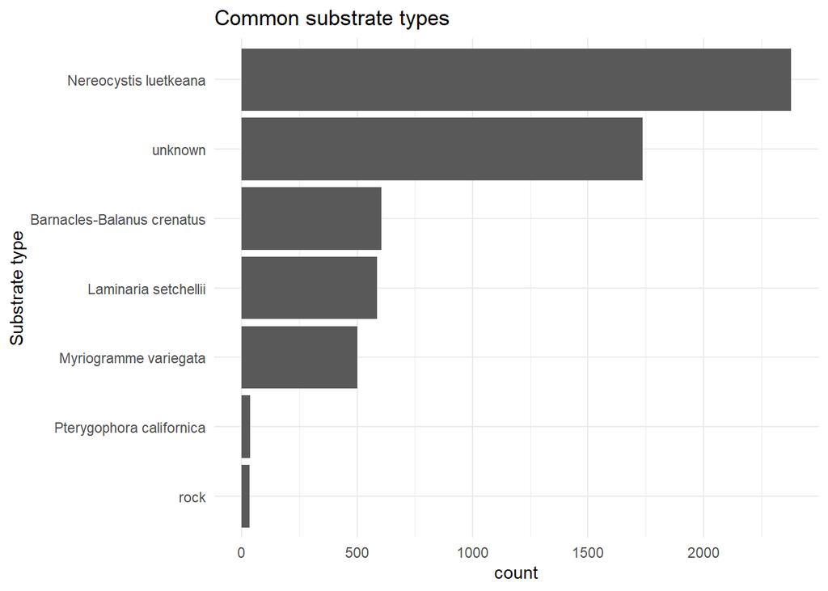

## 4.13 How common were cospecies? Numbers and percentages.

| Cospecies | total | percent |
| --- | --- | --- |
| none | 3810 | 63.1945596 |
| Laminaria setchellii | 1459 | 24.1997014 |
| Callophyllis crenulata | 192 | 3.1846077 |
| Desmarestia linglata | 162 | 2.6870128 |
| Alaria marginata | 76 | 1.2605739 |
| Callophyllis pinnata | 59 | 0.9786034 |
| Callophyllis fabellulata | 57 | 0.9454304 |
| hydroid | 39 | 0.6468734 |
| Hymenena flabelligera | 35 | 0.5805275 |
| Polyneura latissima | 17 | 0.2819705 |
| Costaria costata | 16 | 0.2653840 |
| Callophyllis linearis | 15 | 0.2487975 |
| Membranoptera dimorpha | 13 | 0.2156245 |
| Antithamionella pacifica | 11 | 0.1824515 |
| Ulva lactuca | 10 | 0.1658650 |
| Hymenena cuneifolia | 6 | 0.0995190 |
| Mazzaella splendens | 6 | 0.0995190 |
| Pyropia nereocystis | 6 | 0.0995190 |
| Bryozoa-Celleporella | 5 | 0.0829325 |
| Bossiella sp. | 4 | 0.0663460 |
| Isabbottia ovalifolia | 4 | 0.0663460 |
| Lessoniopsis littoralis | 4 | 0.0663460 |
| Rhodymenia californica | 4 | 0.0663460 |
| unknown | 4 | 0.0663460 |
| Hymenena multiloba | 3 | 0.0497595 |
| Membranoptera weeksiae | 3 | 0.0497595 |
| Pterosiphonia dendroidea | 3 | 0.0497595 |
| Crustose red algae | 1 | 0.0165865 |
| Dilsea californica | 1 | 0.0165865 |
| Egregia menziesii | 1 | 0.0165865 |
| Polysiphonia pacifica | 1 | 0.0165865 |
| Prionitis lanceolata | 1 | 0.0165865 |
| Rhodymenia pacifica | 1 | 0.0165865 |

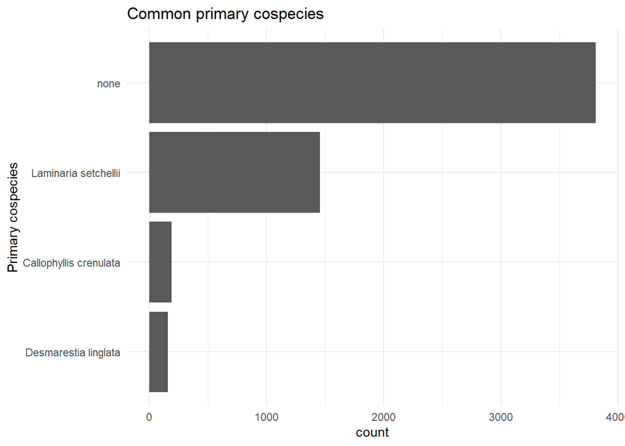

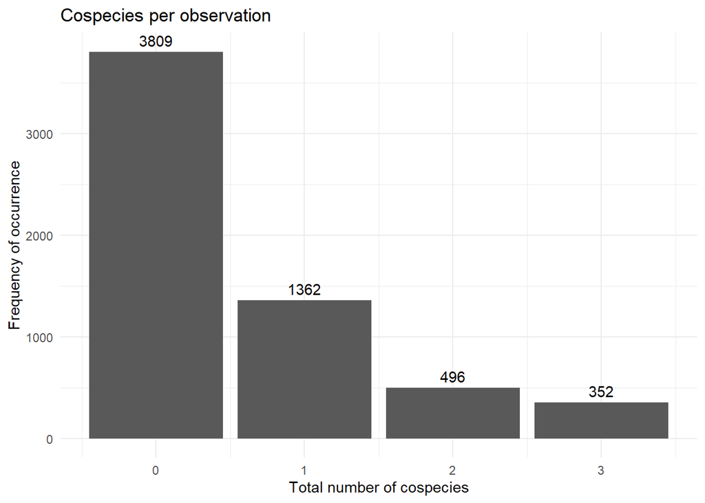

# 5 References

Amsler, Charles D, and Michael Neushul. 1989. “Diel Periodicity of Spore Release from the Kelp Nereocystis Luetkeana (Mertens) Postels Et Ruprecht.” *Journal of Experimental Marine Biology and Ecology* 134 (2): 117–27.

Collins, R., F. Wendell, P. Kalvass, B. Ota, J. Kashiwada, I. Tanaguchi, A. King, et al. 2001. “Giant and Bull Kelp Commercial and Sport Fishing Regulations.” 2000012089. Sacramento, CA, USA: California Department of Fish; Game. https://nrm.dfg.ca.gov/FileHandler.ashx?DocumentID=34384.

Dieck, Inka tom. 1993. “Temperature Tolerance and Survival in Darkness of Kelp Gametophytes (Laminariales, Phaeophyta): Ecological and Biogeographical Implications.” *MARINE ECOLOGY-PROGRESS SERIES* 100: 253–53.

Dobkowski, Katie A., K. Darby Flanagan, and Jessica R. Nordstrom. 2019. “Factors Influencing Recruitment and Appearance of Bull Kelp, *Nereocystis Luetkeana* (Phylum Ochrophyta).” Edited by A. Buschmann. *Journal of Phycology* 55 (1): 236–44. https://doi.org/10.1111/jpy.12814.

Foreman, Ronald Eugene. 1970. *PHYSIOLOGY, ECOLOGY, AND DEVELOPMENT OF THE BROWN ALGA, NEREOCYSTIS LUETKEANA (MERTENS) p. & r.* University of California, Berkeley.

García-Reyes, Marisol, Sarah Ann Thompson, Laura Rogers-Bennett, and William J. Sydeman. 2022. “Winter Oceanographic Conditions Predict Summer Bull Kelp Canopy Cover in Northern California.” Edited by Eliza Heery. *PLOS ONE* 17 (5): e0267737. https://doi.org/10.1371/journal.pone.0267737.

Maxell, B. A., and K. A. Miller. 1996. “Demographic Studies of the Annual Kelps Nereocystis Luetkeana and Costaria Costata (Laminariales, Phaeophyta) in Puget Sound, Washington.” *Botanica Marina* 39 (1-6). https://doi.org/10.1515/botm.1996.39.1-6.479.

Miller, K. A., and J. A. Estes. 1989. “Western Range Extension for Nereocystis Luetkeana in the North Pacific Ocean.” *Botm* 32 (6): 535–38. https://doi.org/10.1515/botm.1989.32.6.535.

Picard, Manon M. M., Ladd E. Johnson, and Isabelle M. Côté. 2022. “Effects of Sediment on Spore Performance as a Potential Constraint on Kelp Distribution.” *Marine Pollution Bulletin* 185 (December): 114336. https://doi.org/10.1016/j.marpolbul.2022.114336.

Springer, Yuri P, Cynthia G Hays, Mark H Carr, and Megan R Mackey. 2010. “Toward Ecosystem-Based Management of Marine Macroalgae — The Bull Kelp, Nereocystis Luetkeana.”

Springer, Yuri, Cynthia Hays, Mark Carr, M Mackey, and J Bloeser. 2007. “Ecology and Management of the Bull Kelp, Nereocystis Luetkeana.” *Lenfest Ocean Program, Washington, DC*.

Weigel, Brooke L., Sadie L. Small, Helen D. Berry, and Megan N. Dethier. 2023. “Effects of Temperature and Nutrients on Microscopic Stages of the Bull Kelp ( *Nereocystis Luetkeana* , Phaeophyceae).” *Journal of Phycology*, July, jpy.13366. https://doi.org/10.1111/jpy.13366.